# Risk Factor Analysis

## Outcome Variable

**Outcome Variable:** stunted

## Predictor Variables

**Intervention Variable:** tr

**Adjustment Set:**

unadjusted

## Stratifying Variables

The analysis was stratified on these variable(s):

- agecat
- studyid
- country
- intXparity

## Data Summary

| agecat | studyid | country | intXparity | stunted | n_cell | n |
| --- | --- | --- | --- | --- | --- | --- |
| Birth | iLiNS_DYADM_LNS | MALAWI | 1_Birth | 0 | 0 | 1 |
| Birth | iLiNS_DYADM_LNS | MALAWI | 1_Birth | 1 | 1 | 1 |
| Birth | ki1000304b-SAS-CompFeed | INDIA | 1_Birth | 0 | 27 | 39 |
| Birth | ki1000304b-SAS-CompFeed | INDIA | 1_Birth | 1 | 12 | 39 |
| Birth | ki1000304b-SAS-CompFeed | INDIA | 2_Birth | 0 | 30 | 42 |
| Birth | ki1000304b-SAS-CompFeed | INDIA | 2_Birth | 1 | 12 | 42 |
| Birth | ki1000304b-SAS-CompFeed | INDIA | 3+_Birth | 0 | 49 | 63 |
| Birth | ki1000304b-SAS-CompFeed | INDIA | 3+_Birth | 1 | 14 | 63 |
| Birth | ki1126311-ZVITAMBO | ZIMBABWE | 1_Birth | 0 | 5332 | 5972 |
| Birth | ki1126311-ZVITAMBO | ZIMBABWE | 1_Birth | 1 | 640 | 5972 |
| Birth | ki1126311-ZVITAMBO | ZIMBABWE | 2_Birth | 0 | 3718 | 4125 |
| Birth | ki1126311-ZVITAMBO | ZIMBABWE | 2_Birth | 1 | 407 | 4125 |
| Birth | ki1126311-ZVITAMBO | ZIMBABWE | 3+_Birth | 0 | 3347 | 3732 |
| Birth | ki1126311-ZVITAMBO | ZIMBABWE | 3+_Birth | 1 | 385 | 3732 |
| Birth | ki1135781-COHORTS | GUATEMALA | 1_Birth | 0 | 103 | 112 |
| Birth | ki1135781-COHORTS | GUATEMALA | 1_Birth | 1 | 9 | 112 |
| Birth | ki1135781-COHORTS | GUATEMALA | 2_Birth | 0 | 124 | 137 |
| Birth | ki1135781-COHORTS | GUATEMALA | 2_Birth | 1 | 13 | 137 |
| Birth | ki1135781-COHORTS | GUATEMALA | 3+_Birth | 0 | 575 | 603 |
| Birth | ki1135781-COHORTS | GUATEMALA | 3+_Birth | 1 | 28 | 603 |
| Birth | ki1148112-iLiNS-DYAD-M | MALAWI | 1_Birth | 0 | 0 | 1 |
| Birth | ki1148112-iLiNS-DYAD-M | MALAWI | 1_Birth | 1 | 1 | 1 |
| Birth | kiGH5241-JiVitA-3 | BANGLADESH | 1_Birth | 0 | 7554 | 12542 |
| Birth | kiGH5241-JiVitA-3 | BANGLADESH | 1_Birth | 1 | 4988 | 12542 |
| Birth | kiGH5241-JiVitA-3 | BANGLADESH | 2_Birth | 0 | 9422 | 13420 |
| Birth | kiGH5241-JiVitA-3 | BANGLADESH | 2_Birth | 1 | 3998 | 13420 |
| Birth | kiGH5241-JiVitA-3 | BANGLADESH | 3+_Birth | 0 | 9544 | 13226 |
| Birth | kiGH5241-JiVitA-3 | BANGLADESH | 3+_Birth | 1 | 3682 | 13226 |
| 6 months | iLiNS_DYADM_LNS | MALAWI | 1_6 months | 0 | 94 | 122 |
| 6 months | iLiNS_DYADM_LNS | MALAWI | 1_6 months | 1 | 28 | 122 |

[output cut: 114 more lines]

The following strata were considered:

- agecat: 24 months, studyid: iLiNS_DYADM_LNS, country: MALAWI, intXparity: 1_24 months
- agecat: 24 months, studyid: iLiNS_DYADM_LNS, country: MALAWI, intXparity: 2_24 months
- agecat: 24 months, studyid: iLiNS_DYADM_LNS, country: MALAWI, intXparity: 3+_24 months
- agecat: 24 months, studyid: ki1000110-WASH-Bangladesh, country: BANGLADESH, intXparity: 1_24 months
- agecat: 24 months, studyid: ki1000110-WASH-Bangladesh, country: BANGLADESH, intXparity: 2_24 months
- agecat: 24 months, studyid: ki1000110-WASH-Bangladesh, country: BANGLADESH, intXparity: 3+_24 months
- agecat: 24 months, studyid: ki1017093b-PROVIDE, country: BANGLADESH, intXparity: 1_24 months
- agecat: 24 months, studyid: ki1017093b-PROVIDE, country: BANGLADESH, intXparity: 2_24 months
- agecat: 24 months, studyid: ki1066203-TanzaniaChild2, country: TANZANIA, UNITED REPUBLIC OF, intXparity: 1_24 months
- agecat: 24 months, studyid: ki1066203-TanzaniaChild2, country: TANZANIA, UNITED REPUBLIC OF, intXparity: 3+_24 months
- agecat: 24 months, studyid: ki1112895-Burkina Faso Zn, country: BURKINA FASO, intXparity: 1_24 months
- agecat: 24 months, studyid: ki1112895-Burkina Faso Zn, country: BURKINA FASO, intXparity: 2_24 months
- agecat: 24 months, studyid: ki1112895-Burkina Faso Zn, country: BURKINA FASO, intXparity: 3+_24 months
- agecat: 24 months, studyid: ki1126311-ZVITAMBO, country: ZIMBABWE, intXparity: 1_24 months
- agecat: 24 months, studyid: ki1126311-ZVITAMBO, country: ZIMBABWE, intXparity: 2_24 months
- agecat: 24 months, studyid: ki1126311-ZVITAMBO, country: ZIMBABWE, intXparity: 3+_24 months
- agecat: 24 months, studyid: ki1135781-COHORTS, country: GUATEMALA, intXparity: 1_24 months
- agecat: 24 months, studyid: ki1135781-COHORTS, country: GUATEMALA, intXparity: 2_24 months
- agecat: 24 months, studyid: ki1135781-COHORTS, country: GUATEMALA, intXparity: 3+_24 months
- agecat: 24 months, studyid: ki1148112-iLiNS-DYAD-M, country: MALAWI, intXparity: 1_24 months
- agecat: 24 months, studyid: ki1148112-iLiNS-DYAD-M, country: MALAWI, intXparity: 2_24 months
- agecat: 24 months, studyid: ki1148112-iLiNS-DYAD-M, country: MALAWI, intXparity: 3+_24 months
- agecat: 24 months, studyid: kiGH5241-JiVitA-3, country: BANGLADESH, intXparity: 1_24 months
- agecat: 24 months, studyid: kiGH5241-JiVitA-3, country: BANGLADESH, intXparity: 2_24 months
- agecat: 24 months, studyid: kiGH5241-JiVitA-3, country: BANGLADESH, intXparity: 3+_24 months
- agecat: 6 months, studyid: iLiNS_DYADM_LNS, country: MALAWI, intXparity: 1_6 months
- agecat: 6 months, studyid: iLiNS_DYADM_LNS, country: MALAWI, intXparity: 2_6 months
- agecat: 6 months, studyid: iLiNS_DYADM_LNS, country: MALAWI, intXparity: 3+_6 months
- agecat: 6 months, studyid: ki1000110-WASH-Bangladesh, country: BANGLADESH, intXparity: 1_6 months
- agecat: 6 months, studyid: ki1000110-WASH-Bangladesh, country: BANGLADESH, intXparity: 2_6 months
- agecat: 6 months, studyid: ki1000110-WASH-Bangladesh, country: BANGLADESH, intXparity: 3+_6 months
- agecat: 6 months, studyid: ki1000304b-SAS-CompFeed, country: INDIA, intXparity: 1_6 months
- agecat: 6 months, studyid: ki1000304b-SAS-CompFeed, country: INDIA, intXparity: 2_6 months
- agecat: 6 months, studyid: ki1000304b-SAS-CompFeed, country: INDIA, intXparity: 3+_6 months
- agecat: 6 months, studyid: ki1000304b-SAS-FoodSuppl, country: INDIA, intXparity: 1_6 months
- agecat: 6 months, studyid: ki1000304b-SAS-FoodSuppl, country: INDIA, intXparity: 2_6 months
- agecat: 6 months, studyid: ki1000304b-SAS-FoodSuppl, country: INDIA, intXparity: 3+_6 months
- agecat: 6 months, studyid: ki1017093b-PROVIDE, country: BANGLADESH, intXparity: 1_6 months
- agecat: 6 months, studyid: ki1017093b-PROVIDE, country: BANGLADESH, intXparity: 2_6 months
- agecat: 6 months, studyid: ki1017093b-PROVIDE, country: BANGLADESH, intXparity: 3+_6 months
- agecat: 6 months, studyid: ki1066203-TanzaniaChild2, country: TANZANIA, UNITED REPUBLIC OF, intXparity: 1_6 months
- agecat: 6 months, studyid: ki1066203-TanzaniaChild2, country: TANZANIA, UNITED REPUBLIC OF, intXparity: 2_6 months
- agecat: 6 months, studyid: ki1066203-TanzaniaChild2, country: TANZANIA, UNITED REPUBLIC OF, intXparity: 3+_6 months
- agecat: 6 months, studyid: ki1112895-Burkina Faso Zn, country: BURKINA FASO, intXparity: 1_6 months
- agecat: 6 months, studyid: ki1112895-Burkina Faso Zn, country: BURKINA FASO, intXparity: 2_6 months
- agecat: 6 months, studyid: ki1112895-Burkina Faso Zn, country: BURKINA FASO, intXparity: 3+_6 months
- agecat: 6 months, studyid: ki1126311-ZVITAMBO, country: ZIMBABWE, intXparity: 1_6 months
- agecat: 6 months, studyid: ki1126311-ZVITAMBO, country: ZIMBABWE, intXparity: 2_6 months
- agecat: 6 months, studyid: ki1126311-ZVITAMBO, country: ZIMBABWE, intXparity: 3+_6 months
- agecat: 6 months, studyid: ki1135781-COHORTS, country: GUATEMALA, intXparity: 1_6 months
- agecat: 6 months, studyid: ki1135781-COHORTS, country: GUATEMALA, intXparity: 2_6 months
- agecat: 6 months, studyid: ki1135781-COHORTS, country: GUATEMALA, intXparity: 3+_6 months
- agecat: 6 months, studyid: ki1148112-iLiNS-DYAD-M, country: MALAWI, intXparity: 1_6 months
- agecat: 6 months, studyid: ki1148112-iLiNS-DYAD-M, country: MALAWI, intXparity: 2_6 months
- agecat: 6 months, studyid: ki1148112-iLiNS-DYAD-M, country: MALAWI, intXparity: 3+_6 months
- agecat: 6 months, studyid: kiGH5241-JiVitA-3, country: BANGLADESH, intXparity: 1_6 months
- agecat: 6 months, studyid: kiGH5241-JiVitA-3, country: BANGLADESH, intXparity: 2_6 months
- agecat: 6 months, studyid: kiGH5241-JiVitA-3, country: BANGLADESH, intXparity: 3+_6 months
- agecat: Birth, studyid: iLiNS_DYADM_LNS, country: MALAWI, intXparity: 1_Birth
- agecat: Birth, studyid: ki1000304b-SAS-CompFeed, country: INDIA, intXparity: 1_Birth
- agecat: Birth, studyid: ki1000304b-SAS-CompFeed, country: INDIA, intXparity: 2_Birth
- agecat: Birth, studyid: ki1000304b-SAS-CompFeed, country: INDIA, intXparity: 3+_Birth
- agecat: Birth, studyid: ki1126311-ZVITAMBO, country: ZIMBABWE, intXparity: 1_Birth
- agecat: Birth, studyid: ki1126311-ZVITAMBO, country: ZIMBABWE, intXparity: 2_Birth
- agecat: Birth, studyid: ki1126311-ZVITAMBO, country: ZIMBABWE, intXparity: 3+_Birth
- agecat: Birth, studyid: ki1135781-COHORTS, country: GUATEMALA, intXparity: 1_Birth
- agecat: Birth, studyid: ki1135781-COHORTS, country: GUATEMALA, intXparity: 2_Birth
- agecat: Birth, studyid: ki1135781-COHORTS, country: GUATEMALA, intXparity: 3+_Birth
- agecat: Birth, studyid: ki1148112-iLiNS-DYAD-M, country: MALAWI, intXparity: 1_Birth
- agecat: Birth, studyid: kiGH5241-JiVitA-3, country: BANGLADESH, intXparity: 1_Birth
- agecat: Birth, studyid: kiGH5241-JiVitA-3, country: BANGLADESH, intXparity: 2_Birth
- agecat: Birth, studyid: kiGH5241-JiVitA-3, country: BANGLADESH, intXparity: 3+_Birth

### Dropped Strata

Some strata were dropped due to rare outcomes:

- agecat: Birth, studyid: iLiNS_DYADM_LNS, country: MALAWI, intXparity: 1_Birth
- agecat: Birth, studyid: ki1148112-iLiNS-DYAD-M, country: MALAWI, intXparity: 1_Birth
- agecat: 6 months, studyid: ki1017093b-PROVIDE, country: BANGLADESH, intXparity: 2_6 months
- agecat: 6 months, studyid: ki1017093b-PROVIDE, country: BANGLADESH, intXparity: 3+_6 months
- agecat: 24 months, studyid: iLiNS_DYADM_LNS, country: MALAWI, intXparity: 1_24 months
- agecat: 24 months, studyid: iLiNS_DYADM_LNS, country: MALAWI, intXparity: 2_24 months
- agecat: 24 months, studyid: ki1017093b-PROVIDE, country: BANGLADESH, intXparity: 1_24 months
- agecat: 24 months, studyid: ki1017093b-PROVIDE, country: BANGLADESH, intXparity: 2_24 months
- agecat: 24 months, studyid: ki1066203-TanzaniaChild2, country: TANZANIA, UNITED REPUBLIC OF, intXparity: 1_24 months
- agecat: 24 months, studyid: ki1066203-TanzaniaChild2, country: TANZANIA, UNITED REPUBLIC OF, intXparity: 3+_24 months
- agecat: 24 months, studyid: ki1126311-ZVITAMBO, country: ZIMBABWE, intXparity: 2_24 months
- agecat: 24 months, studyid: ki1126311-ZVITAMBO, country: ZIMBABWE, intXparity: 3+_24 months
- agecat: 24 months, studyid: ki1148112-iLiNS-DYAD-M, country: MALAWI, intXparity: 1_24 months

## Methods Detail

We’re interested in the causal parameters $E[Y_a]$ for all values of $a \in \mathcal{A}$. These parameters represent the mean outcome if, possibly contrary to fact, we intervened to set all units to have $A=a$. Under the randomization and positivity assumptions, these are identified by the statistical parameters $\psi_a=E_W[E_{Y|A,W}(Y|A=a,W)]$. In addition, we’re interested in the mean of $Y$, $E[Y]$ under no intervention (the observed mean). We will estimate these parameters by using SuperLearner to fit the relevant likelihood factors – $E_{Y|A,W}(Y|A=a,W)$ and $p(A=a|W)$, and then updating our likelihood fit using a joint TMLE.

For unadjusted analyses ($W=\{\}$), initial likelihoods were estimated using Lrnr_glm to estimate the simple $E(Y|A)$ and Lrnr_mean to estimate $p(A)$. For adjusted analyses, a small library containing Lrnr_glmnet, Lrnr_xgboost, and Lrnr_mean was used.

Having estimated these parameters, we will then use the delta method to estimate relative risks and attributable risks relative to a prespecified baseline level of $A$.

[output not shown]

# Results Detail

## Results Plots

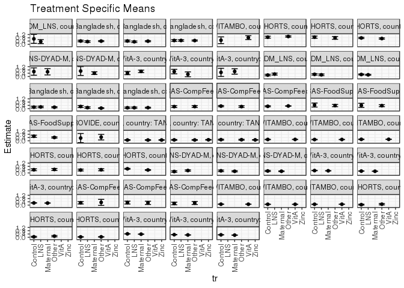

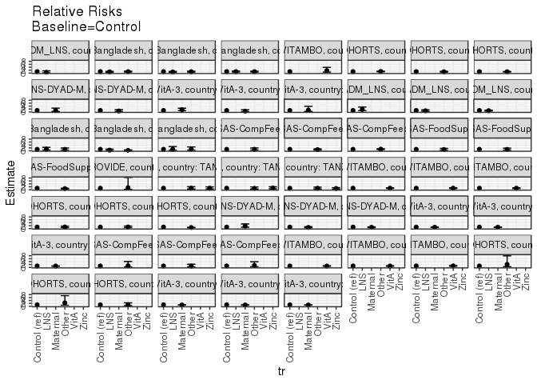

[figure not shown]

[figure not shown]

## Results Table

### Parameter: TSM

| agecat | studyid | country | intXparity | intervention_level | baseline_level | estimate | ci_lower | ci_upper |
| --- | --- | --- | --- | --- | --- | --- | --- | --- |
| Birth | ki1000304b-SAS-CompFeed | INDIA | 1_Birth | Control | NA | 0.2857143 | 0.1396283 | 0.4318003 |
| Birth | ki1000304b-SAS-CompFeed | INDIA | 1_Birth | Other | NA | 0.3333333 | -0.0341549 | 0.7008216 |
| Birth | ki1000304b-SAS-CompFeed | INDIA | 2_Birth | Control | NA | 0.3076923 | 0.1322634 | 0.4831213 |
| Birth | ki1000304b-SAS-CompFeed | INDIA | 2_Birth | Other | NA | 0.2758621 | 0.0789503 | 0.4727738 |
| Birth | ki1000304b-SAS-CompFeed | INDIA | 3+_Birth | Control | NA | 0.1944444 | 0.0337544 | 0.3551345 |
| Birth | ki1000304b-SAS-CompFeed | INDIA | 3+_Birth | Other | NA | 0.2592593 | 0.0747111 | 0.4438074 |
| Birth | ki1126311-ZVITAMBO | ZIMBABWE | 1_Birth | Control | NA | 0.1108844 | 0.0948320 | 0.1269368 |
| Birth | ki1126311-ZVITAMBO | ZIMBABWE | 1_Birth | VitA | NA | 0.1059529 | 0.0969617 | 0.1149441 |
| Birth | ki1126311-ZVITAMBO | ZIMBABWE | 2_Birth | Control | NA | 0.1000991 | 0.0815780 | 0.1186202 |
| Birth | ki1126311-ZVITAMBO | ZIMBABWE | 2_Birth | VitA | NA | 0.0982028 | 0.0877528 | 0.1086529 |
| Birth | ki1126311-ZVITAMBO | ZIMBABWE | 3+_Birth | Control | NA | 0.0989691 | 0.0801742 | 0.1177640 |
| Birth | ki1126311-ZVITAMBO | ZIMBABWE | 3+_Birth | VitA | NA | 0.1046343 | 0.0932179 | 0.1160508 |
| Birth | ki1135781-COHORTS | GUATEMALA | 1_Birth | Control | NA | 0.0526316 | -0.0055976 | 0.1108608 |
| Birth | ki1135781-COHORTS | GUATEMALA | 1_Birth | Other | NA | 0.1090909 | 0.0263300 | 0.1918518 |
| Birth | ki1135781-COHORTS | GUATEMALA | 2_Birth | Control | NA | 0.0571429 | 0.0025678 | 0.1117179 |
| Birth | ki1135781-COHORTS | GUATEMALA | 2_Birth | Other | NA | 0.1343284 | 0.0523759 | 0.2162808 |
| Birth | ki1135781-COHORTS | GUATEMALA | 3+_Birth | Control | NA | 0.0428571 | 0.0191145 | 0.0665998 |
| Birth | ki1135781-COHORTS | GUATEMALA | 3+_Birth | Other | NA | 0.0495356 | 0.0258528 | 0.0732185 |
| Birth | kiGH5241-JiVitA-3 | BANGLADESH | 1_Birth | Control | NA | 0.4177296 | 0.3991533 | 0.4363059 |
| Birth | kiGH5241-JiVitA-3 | BANGLADESH | 1_Birth | Maternal | NA | 0.3776715 | 0.3583456 | 0.3969973 |
| Birth | kiGH5241-JiVitA-3 | BANGLADESH | 2_Birth | Control | NA | 0.3136377 | 0.2950029 | 0.3322726 |
| Birth | kiGH5241-JiVitA-3 | BANGLADESH | 2_Birth | Maternal | NA | 0.2822269 | 0.2655764 | 0.2988773 |
| Birth | kiGH5241-JiVitA-3 | BANGLADESH | 3+_Birth | Control | NA | 0.2962735 | 0.2770068 | 0.3155402 |
| Birth | kiGH5241-JiVitA-3 | BANGLADESH | 3+_Birth | Maternal | NA | 0.2611408 | 0.2437486 | 0.2785330 |
| 6 months | iLiNS_DYADM_LNS | MALAWI | 1_6 months | Control | NA | 0.1718750 | 0.0790640 | 0.2646860 |
| 6 months | iLiNS_DYADM_LNS | MALAWI | 1_6 months | LNS | NA | 0.2931034 | 0.1754757 | 0.4107312 |
| 6 months | iLiNS_DYADM_LNS | MALAWI | 2_6 months | Control | NA | 0.2613636 | 0.1692597 | 0.3534675 |
| 6 months | iLiNS_DYADM_LNS | MALAWI | 2_6 months | LNS | NA | 0.2031250 | 0.1042314 | 0.3020186 |
| 6 months | iLiNS_DYADM_LNS | MALAWI | 3+_6 months | Control | NA | 0.2424242 | 0.1826589 | 0.3021896 |
| 6 months | iLiNS_DYADM_LNS | MALAWI | 3+_6 months | LNS | NA | 0.2047619 | 0.1501177 | 0.2594062 |

[output cut: 85 more lines]

### Parameter: E(Y)

| agecat | studyid | country | intXparity | intervention_level | baseline_level | estimate | ci_lower | ci_upper |
| --- | --- | --- | --- | --- | --- | --- | --- | --- |
| Birth | ki1000304b-SAS-CompFeed | INDIA | 1_Birth | NA | NA | 0.3076923 | 0.1203158 | 0.4950688 |
| Birth | ki1000304b-SAS-CompFeed | INDIA | 2_Birth | NA | NA | 0.2857143 | 0.1356543 | 0.4357743 |
| Birth | ki1000304b-SAS-CompFeed | INDIA | 3+_Birth | NA | NA | 0.2222222 | 0.0905686 | 0.3538758 |
| Birth | ki1126311-ZVITAMBO | ZIMBABWE | 1_Birth | NA | NA | 0.1071668 | 0.0993209 | 0.1150126 |
| Birth | ki1126311-ZVITAMBO | ZIMBABWE | 2_Birth | NA | NA | 0.0986667 | 0.0895651 | 0.1077682 |
| Birth | ki1126311-ZVITAMBO | ZIMBABWE | 3+_Birth | NA | NA | 0.1031618 | 0.0934018 | 0.1129219 |
| Birth | ki1135781-COHORTS | GUATEMALA | 1_Birth | NA | NA | 0.0803571 | 0.0297853 | 0.1309289 |
| Birth | ki1135781-COHORTS | GUATEMALA | 2_Birth | NA | NA | 0.0948905 | 0.0456366 | 0.1441444 |
| Birth | ki1135781-COHORTS | GUATEMALA | 3+_Birth | NA | NA | 0.0464345 | 0.0296254 | 0.0632436 |
| Birth | kiGH5241-JiVitA-3 | BANGLADESH | 1_Birth | NA | NA | 0.3977037 | 0.3842293 | 0.4111782 |
| Birth | kiGH5241-JiVitA-3 | BANGLADESH | 2_Birth | NA | NA | 0.2979136 | 0.2853406 | 0.3104865 |
| Birth | kiGH5241-JiVitA-3 | BANGLADESH | 3+_Birth | NA | NA | 0.2783910 | 0.2653337 | 0.2914484 |
| 6 months | iLiNS_DYADM_LNS | MALAWI | 1_6 months | NA | NA | 0.2295082 | 0.1545812 | 0.3044352 |
| 6 months | iLiNS_DYADM_LNS | MALAWI | 2_6 months | NA | NA | 0.2368421 | 0.1690317 | 0.3046525 |
| 6 months | iLiNS_DYADM_LNS | MALAWI | 3+_6 months | NA | NA | 0.2230392 | 0.1825964 | 0.2634820 |
| 6 months | ki1000110-WASH-Bangladesh | BANGLADESH | 1_6 months | NA | NA | 0.1861472 | 0.1358452 | 0.2364492 |
| 6 months | ki1000110-WASH-Bangladesh | BANGLADESH | 2_6 months | NA | NA | 0.1282051 | 0.0811608 | 0.1752494 |
| 6 months | ki1000110-WASH-Bangladesh | BANGLADESH | 3+_6 months | NA | NA | 0.1145374 | 0.0730179 | 0.1560570 |
| 6 months | ki1000304b-SAS-CompFeed | INDIA | 1_6 months | NA | NA | 0.2500000 | 0.1695680 | 0.3304320 |
| 6 months | ki1000304b-SAS-CompFeed | INDIA | 2_6 months | NA | NA | 0.2745098 | 0.2062724 | 0.3427472 |
| 6 months | ki1000304b-SAS-CompFeed | INDIA | 3+_6 months | NA | NA | 0.3028169 | 0.2655366 | 0.3400972 |
| 6 months | ki1000304b-SAS-FoodSuppl | INDIA | 1_6 months | NA | NA | 0.3906250 | 0.2701491 | 0.5111009 |
| 6 months | ki1000304b-SAS-FoodSuppl | INDIA | 2_6 months | NA | NA | 0.3684211 | 0.2592510 | 0.4775911 |
| 6 months | ki1000304b-SAS-FoodSuppl | INDIA | 3+_6 months | NA | NA | 0.4471154 | 0.3793840 | 0.5148468 |
| 6 months | ki1017093b-PROVIDE | BANGLADESH | 1_6 months | NA | NA | 0.4166667 | 0.1253237 | 0.7080096 |
| 6 months | ki1066203-TanzaniaChild2 | TANZANIA, UNITED REPUBLIC OF | 1_6 months | NA | NA | 0.0939716 | 0.0698691 | 0.1180742 |
| 6 months | ki1066203-TanzaniaChild2 | TANZANIA, UNITED REPUBLIC OF | 2_6 months | NA | NA | 0.1135531 | 0.0869167 | 0.1401895 |
| 6 months | ki1066203-TanzaniaChild2 | TANZANIA, UNITED REPUBLIC OF | 3+_6 months | NA | NA | 0.1228070 | 0.0958389 | 0.1497752 |
| 6 months | ki1126311-ZVITAMBO | ZIMBABWE | 1_6 months | NA | NA | 0.1631664 | 0.1501460 | 0.1761868 |
| 6 months | ki1126311-ZVITAMBO | ZIMBABWE | 2_6 months | NA | NA | 0.1561307 | 0.1414738 | 0.1707876 |
| 6 months | ki1126311-ZVITAMBO | ZIMBABWE | 3+_6 months | NA | NA | 0.1795093 | 0.1638995 | 0.1951191 |
| 6 months | ki1135781-COHORTS | GUATEMALA | 1_6 months | NA | NA | 0.4076923 | 0.3228928 | 0.4924918 |
| 6 months | ki1135781-COHORTS | GUATEMALA | 2_6 months | NA | NA | 0.3712121 | 0.2884797 | 0.4539445 |
| 6 months | ki1135781-COHORTS | GUATEMALA | 3+_6 months | NA | NA | 0.4283582 | 0.3908609 | 0.4658556 |
| 6 months | ki1148112-iLiNS-DYAD-M | MALAWI | 1_6 months | NA | NA | 0.2513966 | 0.1876667 | 0.3151266 |
| 6 months | ki1148112-iLiNS-DYAD-M | MALAWI | 2_6 months | NA | NA | 0.2272727 | 0.1717702 | 0.2827753 |
| 6 months | ki1148112-iLiNS-DYAD-M | MALAWI | 3+_6 months | NA | NA | 0.2185008 | 0.1861301 | 0.2508715 |
| 6 months | kiGH5241-JiVitA-3 | BANGLADESH | 1_6 months | NA | NA | 0.2782287 | 0.2651685 | 0.2912889 |
| 6 months | kiGH5241-JiVitA-3 | BANGLADESH | 2_6 months | NA | NA | 0.2169247 | 0.2048081 | 0.2290413 |
| 6 months | kiGH5241-JiVitA-3 | BANGLADESH | 3+_6 months | NA | NA | 0.2569090 | 0.2414520 | 0.2723660 |
| 24 months | iLiNS_DYADM_LNS | MALAWI | 3+_24 months | NA | NA | 0.3888889 | 0.1571513 | 0.6206265 |
| 24 months | ki1000110-WASH-Bangladesh | BANGLADESH | 1_24 months | NA | NA | 0.3819951 | 0.3349645 | 0.4290258 |
| 24 months | ki1000110-WASH-Bangladesh | BANGLADESH | 2_24 months | NA | NA | 0.3723404 | 0.3234116 | 0.4212692 |
| 24 months | ki1000110-WASH-Bangladesh | BANGLADESH | 3+_24 months | NA | NA | 0.4650000 | 0.4160599 | 0.5139401 |
| 24 months | ki1126311-ZVITAMBO | ZIMBABWE | 1_24 months | NA | NA | 0.7058824 | 0.4826204 | 0.9291443 |
| 24 months | ki1135781-COHORTS | GUATEMALA | 1_24 months | NA | NA | 0.9074074 | 0.8293706 | 0.9854442 |
| 24 months | ki1135781-COHORTS | GUATEMALA | 2_24 months | NA | NA | 0.8297872 | 0.7211825 | 0.9383919 |
| 24 months | ki1135781-COHORTS | GUATEMALA | 3+_24 months | NA | NA | 0.7412281 | 0.6842550 | 0.7982011 |
| 24 months | ki1148112-iLiNS-DYAD-M | MALAWI | 2_24 months | NA | NA | 0.5833333 | 0.2919904 | 0.8746763 |
| 24 months | ki1148112-iLiNS-DYAD-M | MALAWI | 3+_24 months | NA | NA | 0.4324324 | 0.2706003 | 0.5942646 |
| 24 months | kiGH5241-JiVitA-3 | BANGLADESH | 1_24 months | NA | NA | 0.5392157 | 0.4140660 | 0.6643654 |
| 24 months | kiGH5241-JiVitA-3 | BANGLADESH | 2_24 months | NA | NA | 0.4571429 | 0.2499949 | 0.6642908 |
| 24 months | kiGH5241-JiVitA-3 | BANGLADESH | 3+_24 months | NA | NA | 0.5714286 | 0.2928514 | 0.8500057 |

### Parameter: RR

| agecat | studyid | country | intXparity | intervention_level | baseline_level | estimate | ci_lower | ci_upper |
| --- | --- | --- | --- | --- | --- | --- | --- | --- |
| Birth | ki1000304b-SAS-CompFeed | INDIA | 1_Birth | Control | Control | 1.0000000 | 1.0000000 | 1.0000000 |
| Birth | ki1000304b-SAS-CompFeed | INDIA | 1_Birth | Other | Control | 1.1666667 | 0.3344619 | 4.0695554 |
| Birth | ki1000304b-SAS-CompFeed | INDIA | 2_Birth | Control | Control | 1.0000000 | 1.0000000 | 1.0000000 |
| Birth | ki1000304b-SAS-CompFeed | INDIA | 2_Birth | Other | Control | 0.8965517 | 0.3631278 | 2.2135594 |
| Birth | ki1000304b-SAS-CompFeed | INDIA | 3+_Birth | Control | Control | 1.0000000 | 1.0000000 | 1.0000000 |
| Birth | ki1000304b-SAS-CompFeed | INDIA | 3+_Birth | Other | Control | 1.3333333 | 0.4564468 | 3.8948189 |
| Birth | ki1126311-ZVITAMBO | ZIMBABWE | 1_Birth | Control | Control | 1.0000000 | 1.0000000 | 1.0000000 |
| Birth | ki1126311-ZVITAMBO | ZIMBABWE | 1_Birth | VitA | Control | 0.9555262 | 0.8079146 | 1.1301075 |
| Birth | ki1126311-ZVITAMBO | ZIMBABWE | 2_Birth | Control | Control | 1.0000000 | 1.0000000 | 1.0000000 |
| Birth | ki1126311-ZVITAMBO | ZIMBABWE | 2_Birth | VitA | Control | 0.9810559 | 0.7924931 | 1.2144847 |
| Birth | ki1126311-ZVITAMBO | ZIMBABWE | 3+_Birth | Control | Control | 1.0000000 | 1.0000000 | 1.0000000 |
| Birth | ki1126311-ZVITAMBO | ZIMBABWE | 3+_Birth | VitA | Control | 1.0572426 | 0.8492901 | 1.3161133 |
| Birth | ki1135781-COHORTS | GUATEMALA | 1_Birth | Control | Control | 1.0000000 | 1.0000000 | 1.0000000 |
| Birth | ki1135781-COHORTS | GUATEMALA | 1_Birth | Other | Control | 2.0727273 | 0.5419341 | 7.9275289 |
| Birth | ki1135781-COHORTS | GUATEMALA | 2_Birth | Control | Control | 1.0000000 | 1.0000000 | 1.0000000 |
| Birth | ki1135781-COHORTS | GUATEMALA | 2_Birth | Other | Control | 2.3507463 | 0.7568720 | 7.3011127 |
| Birth | ki1135781-COHORTS | GUATEMALA | 3+_Birth | Control | Control | 1.0000000 | 1.0000000 | 1.0000000 |
| Birth | ki1135781-COHORTS | GUATEMALA | 3+_Birth | Other | Control | 1.1558307 | 0.5560199 | 2.4026923 |
| Birth | kiGH5241-JiVitA-3 | BANGLADESH | 1_Birth | Control | Control | 1.0000000 | 1.0000000 | 1.0000000 |
| Birth | kiGH5241-JiVitA-3 | BANGLADESH | 1_Birth | Maternal | Control | 0.9041051 | 0.8448095 | 0.9675625 |
| Birth | kiGH5241-JiVitA-3 | BANGLADESH | 2_Birth | Control | Control | 1.0000000 | 1.0000000 | 1.0000000 |
| Birth | kiGH5241-JiVitA-3 | BANGLADESH | 2_Birth | Maternal | Control | 0.8998498 | 0.8275703 | 0.9784422 |
| Birth | kiGH5241-JiVitA-3 | BANGLADESH | 3+_Birth | Control | Control | 1.0000000 | 1.0000000 | 1.0000000 |
| Birth | kiGH5241-JiVitA-3 | BANGLADESH | 3+_Birth | Maternal | Control | 0.8814181 | 0.8030687 | 0.9674115 |
| 6 months | iLiNS_DYADM_LNS | MALAWI | 1_6 months | Control | Control | 1.0000000 | 1.0000000 | 1.0000000 |
| 6 months | iLiNS_DYADM_LNS | MALAWI | 1_6 months | LNS | Control | 1.7053292 | 0.8701999 | 3.3419306 |
| 6 months | iLiNS_DYADM_LNS | MALAWI | 2_6 months | Control | Control | 1.0000000 | 1.0000000 | 1.0000000 |
| 6 months | iLiNS_DYADM_LNS | MALAWI | 2_6 months | LNS | Control | 0.7771739 | 0.4260899 | 1.4175394 |
| 6 months | iLiNS_DYADM_LNS | MALAWI | 3+_6 months | Control | Control | 1.0000000 | 1.0000000 | 1.0000000 |
| 6 months | iLiNS_DYADM_LNS | MALAWI | 3+_6 months | LNS | Control | 0.8446429 | 0.5873384 | 1.2146688 |

[output cut: 85 more lines]

### Parameter: PAR

| agecat | studyid | country | intXparity | intervention_level | baseline_level | estimate | ci_lower | ci_upper |
| --- | --- | --- | --- | --- | --- | --- | --- | --- |
| Birth | ki1000304b-SAS-CompFeed | INDIA | 1_Birth | Control | NA | 0.0219780 | -0.1733167 | 0.2172727 |
| Birth | ki1000304b-SAS-CompFeed | INDIA | 2_Birth | Control | NA | -0.0219780 | -0.2021989 | 0.1582428 |
| Birth | ki1000304b-SAS-CompFeed | INDIA | 3+_Birth | Control | NA | 0.0277778 | -0.0805668 | 0.1361223 |
| Birth | ki1126311-ZVITAMBO | ZIMBABWE | 1_Birth | Control | NA | -0.0037176 | -0.0175878 | 0.0101526 |
| Birth | ki1126311-ZVITAMBO | ZIMBABWE | 2_Birth | Control | NA | -0.0014324 | -0.0174965 | 0.0146317 |
| Birth | ki1126311-ZVITAMBO | ZIMBABWE | 3+_Birth | Control | NA | 0.0041928 | -0.0120823 | 0.0204679 |
| Birth | ki1135781-COHORTS | GUATEMALA | 1_Birth | Control | NA | 0.0277256 | -0.0222440 | 0.0776952 |
| Birth | ki1135781-COHORTS | GUATEMALA | 2_Birth | Control | NA | 0.0377477 | -0.0108396 | 0.0863349 |
| Birth | ki1135781-COHORTS | GUATEMALA | 3+_Birth | Control | NA | 0.0035774 | -0.0143878 | 0.0215425 |
| Birth | kiGH5241-JiVitA-3 | BANGLADESH | 1_Birth | Control | NA | -0.0200259 | -0.0336109 | -0.0064409 |
| Birth | kiGH5241-JiVitA-3 | BANGLADESH | 2_Birth | Control | NA | -0.0157242 | -0.0282749 | -0.0031735 |
| Birth | kiGH5241-JiVitA-3 | BANGLADESH | 3+_Birth | Control | NA | -0.0178824 | -0.0312063 | -0.0045586 |
| 6 months | iLiNS_DYADM_LNS | MALAWI | 1_6 months | Control | NA | 0.0576332 | -0.0144114 | 0.1296778 |
| 6 months | iLiNS_DYADM_LNS | MALAWI | 2_6 months | Control | NA | -0.0245215 | -0.0816075 | 0.0325644 |
| 6 months | iLiNS_DYADM_LNS | MALAWI | 3+_6 months | Control | NA | -0.0193850 | -0.0611064 | 0.0223364 |
| 6 months | ki1000110-WASH-Bangladesh | BANGLADESH | 1_6 months | Control | NA | 0.0024737 | -0.0941056 | 0.0990530 |
| 6 months | ki1000110-WASH-Bangladesh | BANGLADESH | 2_6 months | Control | NA | -0.1317949 | -0.2290149 | -0.0345748 |
| 6 months | ki1000110-WASH-Bangladesh | BANGLADESH | 3+_6 months | Control | NA | 0.0054465 | -0.0669284 | 0.0778214 |
| 6 months | ki1000304b-SAS-CompFeed | INDIA | 1_6 months | Control | NA | 0.0028090 | -0.0785753 | 0.0841933 |
| 6 months | ki1000304b-SAS-CompFeed | INDIA | 2_6 months | Control | NA | -0.0331825 | -0.1116786 | 0.0453136 |
| 6 months | ki1000304b-SAS-CompFeed | INDIA | 3+_6 months | Control | NA | 0.0191290 | -0.0165313 | 0.0547892 |
| 6 months | ki1000304b-SAS-FoodSuppl | INDIA | 1_6 months | Control | NA | -0.0468750 | -0.2578865 | 0.1641365 |
| 6 months | ki1000304b-SAS-FoodSuppl | INDIA | 2_6 months | Control | NA | -0.0315789 | -0.2543246 | 0.1911667 |
| 6 months | ki1000304b-SAS-FoodSuppl | INDIA | 3+_6 months | Control | NA | -0.1064560 | -0.2180337 | 0.0051216 |
| 6 months | ki1017093b-PROVIDE | BANGLADESH | 1_6 months | Control | NA | 0.0833333 | -0.4066577 | 0.5733243 |
| 6 months | ki1066203-TanzaniaChild2 | TANZANIA, UNITED REPUBLIC OF | 1_6 months | Control | NA | 0.0011145 | -0.0406809 | 0.0429099 |
| 6 months | ki1066203-TanzaniaChild2 | TANZANIA, UNITED REPUBLIC OF | 2_6 months | Control | NA | 0.0048575 | -0.0403703 | 0.0500852 |
| 6 months | ki1066203-TanzaniaChild2 | TANZANIA, UNITED REPUBLIC OF | 3+_6 months | Control | NA | -0.0138836 | -0.0628826 | 0.0351154 |
| 6 months | ki1126311-ZVITAMBO | ZIMBABWE | 1_6 months | Control | NA | 0.0027890 | -0.0202873 | 0.0258654 |
| 6 months | ki1126311-ZVITAMBO | ZIMBABWE | 2_6 months | Control | NA | 0.0046155 | -0.0213898 | 0.0306208 |
| 6 months | ki1126311-ZVITAMBO | ZIMBABWE | 3+_6 months | Control | NA | 0.0016952 | -0.0243143 | 0.0277047 |
| 6 months | ki1135781-COHORTS | GUATEMALA | 1_6 months | Control | NA | 0.0163880 | -0.0634155 | 0.0961914 |
| 6 months | ki1135781-COHORTS | GUATEMALA | 2_6 months | Control | NA | 0.0150477 | -0.0594845 | 0.0895799 |
| 6 months | ki1135781-COHORTS | GUATEMALA | 3+_6 months | Control | NA | -0.0780934 | -0.1185600 | -0.0376268 |
| 6 months | ki1148112-iLiNS-DYAD-M | MALAWI | 1_6 months | Control | NA | 0.0795216 | -0.0011586 | 0.1602019 |
| 6 months | ki1148112-iLiNS-DYAD-M | MALAWI | 2_6 months | Control | NA | -0.0340909 | -0.1031828 | 0.0350010 |
| 6 months | ki1148112-iLiNS-DYAD-M | MALAWI | 3+_6 months | Control | NA | -0.0239234 | -0.0725310 | 0.0246841 |
| 6 months | kiGH5241-JiVitA-3 | BANGLADESH | 1_6 months | Control | NA | -0.0130668 | -0.0260117 | -0.0001220 |
| 6 months | kiGH5241-JiVitA-3 | BANGLADESH | 2_6 months | Control | NA | -0.0097585 | -0.0219968 | 0.0024797 |
| 6 months | kiGH5241-JiVitA-3 | BANGLADESH | 3+_6 months | Control | NA | -0.0080690 | -0.0241258 | 0.0079879 |
| 24 months | iLiNS_DYADM_LNS | MALAWI | 3+_24 months | Control | NA | -0.2777778 | -0.7823200 | 0.2267645 |
| 24 months | ki1000110-WASH-Bangladesh | BANGLADESH | 1_24 months | Control | NA | -0.0218510 | -0.1031830 | 0.0594809 |
| 24 months | ki1000110-WASH-Bangladesh | BANGLADESH | 2_24 months | Control | NA | -0.0367505 | -0.1263162 | 0.0528152 |
| 24 months | ki1000110-WASH-Bangladesh | BANGLADESH | 3+_24 months | Control | NA | -0.0033544 | -0.1020394 | 0.0953305 |
| 24 months | ki1126311-ZVITAMBO | ZIMBABWE | 1_24 months | Control | NA | 0.2058824 | -0.1101318 | 0.5218965 |
| 24 months | ki1135781-COHORTS | GUATEMALA | 1_24 months | Control | NA | 0.0364397 | -0.0267083 | 0.0995876 |
| 24 months | ki1135781-COHORTS | GUATEMALA | 2_24 months | Control | NA | -0.0452128 | -0.1520510 | 0.0616254 |
| 24 months | ki1135781-COHORTS | GUATEMALA | 3+_24 months | Control | NA | -0.0355576 | -0.0934431 | 0.0223278 |
| 24 months | ki1148112-iLiNS-DYAD-M | MALAWI | 2_24 months | Control | NA | -0.0166667 | -0.3607687 | 0.3274353 |
| 24 months | ki1148112-iLiNS-DYAD-M | MALAWI | 3+_24 months | Control | NA | -0.2342342 | -0.7550230 | 0.2865546 |
| 24 months | kiGH5241-JiVitA-3 | BANGLADESH | 1_24 months | Control | NA | 0.1206110 | -0.0267704 | 0.2679924 |
| 24 months | kiGH5241-JiVitA-3 | BANGLADESH | 2_24 months | Control | NA | -0.1428571 | -0.3296219 | 0.0439077 |
| 24 months | kiGH5241-JiVitA-3 | BANGLADESH | 3+_24 months | Control | NA | 0.0714286 | -0.3104633 | 0.4533204 |

### Parameter: PAF

| agecat | studyid | country | intXparity | intervention_level | baseline_level | estimate | ci_lower | ci_upper |
| --- | --- | --- | --- | --- | --- | --- | --- | --- |
| Birth | ki1000304b-SAS-CompFeed | INDIA | 1_Birth | Control | NA | 0.0714286 | -0.7807537 | 0.5157978 |
| Birth | ki1000304b-SAS-CompFeed | INDIA | 2_Birth | Control | NA | -0.0769231 | -0.9690655 | 0.4110082 |
| Birth | ki1000304b-SAS-CompFeed | INDIA | 3+_Birth | Control | NA | 0.1250000 | -0.5226403 | 0.4971728 |
| Birth | ki1126311-ZVITAMBO | ZIMBABWE | 1_Birth | Control | NA | -0.0346896 | -0.1725376 | 0.0869524 |
| Birth | ki1126311-ZVITAMBO | ZIMBABWE | 2_Birth | Control | NA | -0.0145180 | -0.1911169 | 0.1358978 |
| Birth | ki1126311-ZVITAMBO | ZIMBABWE | 3+_Birth | Control | NA | 0.0406426 | -0.1307899 | 0.1860853 |
| Birth | ki1135781-COHORTS | GUATEMALA | 1_Birth | Control | NA | 0.3450292 | -0.6056629 | 0.7328289 |
| Birth | ki1135781-COHORTS | GUATEMALA | 2_Birth | Control | NA | 0.3978022 | -0.3236449 | 0.7260276 |
| Birth | ki1135781-COHORTS | GUATEMALA | 3+_Birth | Control | NA | 0.0770408 | -0.4021736 | 0.3924763 |
| Birth | kiGH5241-JiVitA-3 | BANGLADESH | 1_Birth | Control | NA | -0.0503538 | -0.0852188 | -0.0166088 |
| Birth | kiGH5241-JiVitA-3 | BANGLADESH | 2_Birth | Control | NA | -0.0527809 | -0.0955923 | -0.0116425 |
| Birth | kiGH5241-JiVitA-3 | BANGLADESH | 3+_Birth | Control | NA | -0.0642350 | -0.1130767 | -0.0175363 |
| 6 months | iLiNS_DYADM_LNS | MALAWI | 1_6 months | Control | NA | 0.2511161 | -0.1297584 | 0.5035867 |
| 6 months | iLiNS_DYADM_LNS | MALAWI | 2_6 months | Control | NA | -0.1035354 | -0.3721980 | 0.1125259 |
| 6 months | iLiNS_DYADM_LNS | MALAWI | 3+_6 months | Control | NA | -0.0869131 | -0.2907360 | 0.0847237 |
| 6 months | ki1000110-WASH-Bangladesh | BANGLADESH | 1_6 months | Control | NA | 0.0132890 | -0.6693520 | 0.4167806 |
| 6 months | ki1000110-WASH-Bangladesh | BANGLADESH | 2_6 months | Control | NA | -1.0280000 | -1.8916110 | -0.4223158 |
| 6 months | ki1000110-WASH-Bangladesh | BANGLADESH | 3+_6 months | Control | NA | 0.0475524 | -0.8487879 | 0.5093237 |
| 6 months | ki1000304b-SAS-CompFeed | INDIA | 1_6 months | Control | NA | 0.0112360 | -0.3743142 | 0.2886239 |
| 6 months | ki1000304b-SAS-CompFeed | INDIA | 2_6 months | Control | NA | -0.1208791 | -0.4659917 | 0.1429897 |
| 6 months | ki1000304b-SAS-CompFeed | INDIA | 3+_6 months | Control | NA | 0.0631700 | -0.0670198 | 0.1774751 |
| 6 months | ki1000304b-SAS-FoodSuppl | INDIA | 1_6 months | Control | NA | -0.1200000 | -0.8150877 | 0.3089039 |
| 6 months | ki1000304b-SAS-FoodSuppl | INDIA | 2_6 months | Control | NA | -0.0857143 | -0.8950272 | 0.3779638 |
| 6 months | ki1000304b-SAS-FoodSuppl | INDIA | 3+_6 months | Control | NA | -0.2380952 | -0.5177565 | -0.0099643 |
| 6 months | ki1017093b-PROVIDE | BANGLADESH | 1_6 months | Control | NA | 0.2000000 | -2.4844615 | 0.8163274 |
| 6 months | ki1066203-TanzaniaChild2 | TANZANIA, UNITED REPUBLIC OF | 1_6 months | Control | NA | 0.0118598 | -0.5498607 | 0.3699944 |
| 6 months | ki1066203-TanzaniaChild2 | TANZANIA, UNITED REPUBLIC OF | 2_6 months | Control | NA | 0.0427770 | -0.4510343 | 0.3685360 |
| 6 months | ki1066203-TanzaniaChild2 | TANZANIA, UNITED REPUBLIC OF | 3+_6 months | Control | NA | -0.1130524 | -0.5921648 | 0.2218860 |
| 6 months | ki1126311-ZVITAMBO | ZIMBABWE | 1_6 months | Control | NA | 0.0170932 | -0.1350117 | 0.1488143 |
| 6 months | ki1126311-ZVITAMBO | ZIMBABWE | 2_6 months | Control | NA | 0.0295619 | -0.1521295 | 0.1826005 |
| 6 months | ki1126311-ZVITAMBO | ZIMBABWE | 3+_6 months | Control | NA | 0.0094437 | -0.1465802 | 0.1442362 |
| 6 months | ki1135781-COHORTS | GUATEMALA | 1_6 months | Control | NA | 0.0401969 | -0.1770071 | 0.2173182 |
| 6 months | ki1135781-COHORTS | GUATEMALA | 2_6 months | Control | NA | 0.0405368 | -0.1828305 | 0.2217231 |
| 6 months | ki1135781-COHORTS | GUATEMALA | 3+_6 months | Control | NA | -0.1823086 | -0.2817759 | -0.0905601 |
| 6 months | ki1148112-iLiNS-DYAD-M | MALAWI | 1_6 months | Control | NA | 0.3163194 | -0.0845393 | 0.5690160 |
| 6 months | ki1148112-iLiNS-DYAD-M | MALAWI | 2_6 months | Control | NA | -0.1500000 | -0.4970432 | 0.1165919 |
| 6 months | ki1148112-iLiNS-DYAD-M | MALAWI | 3+_6 months | Control | NA | -0.1094891 | -0.3555446 | 0.0919030 |
| 6 months | kiGH5241-JiVitA-3 | BANGLADESH | 1_6 months | Control | NA | -0.0469644 | -0.0944876 | -0.0015047 |
| 6 months | kiGH5241-JiVitA-3 | BANGLADESH | 2_6 months | Control | NA | -0.0449859 | -0.1029618 | 0.0099426 |
| 6 months | kiGH5241-JiVitA-3 | BANGLADESH | 3+_6 months | Control | NA | -0.0314079 | -0.0956960 | 0.0291083 |
| 24 months | iLiNS_DYADM_LNS | MALAWI | 3+_24 months | Control | NA | -0.7142857 | -2.8286161 | 0.2324183 |
| 24 months | ki1000110-WASH-Bangladesh | BANGLADESH | 1_24 months | Control | NA | -0.0572024 | -0.2931142 | 0.1356704 |
| 24 months | ki1000110-WASH-Bangladesh | BANGLADESH | 2_24 months | Control | NA | -0.0987013 | -0.3677455 | 0.1174202 |
| 24 months | ki1000110-WASH-Bangladesh | BANGLADESH | 3+_24 months | Control | NA | -0.0072138 | -0.2434561 | 0.1841452 |
| 24 months | ki1126311-ZVITAMBO | ZIMBABWE | 1_24 months | Control | NA | 0.2916667 | -0.3752155 | 0.6351582 |
| 24 months | ki1135781-COHORTS | GUATEMALA | 1_24 months | Control | NA | 0.0401580 | -0.0336434 | 0.1086900 |
| 24 months | ki1135781-COHORTS | GUATEMALA | 2_24 months | Control | NA | -0.0544872 | -0.1934896 | 0.0683260 |
| 24 months | ki1135781-COHORTS | GUATEMALA | 3+_24 months | Control | NA | -0.0479713 | -0.1295167 | 0.0276870 |
| 24 months | ki1148112-iLiNS-DYAD-M | MALAWI | 2_24 months | Control | NA | -0.0285714 | -0.8257477 | 0.4205337 |
| 24 months | ki1148112-iLiNS-DYAD-M | MALAWI | 3+_24 months | Control | NA | -0.5416667 | -2.4172552 | 0.3044897 |
| 24 months | kiGH5241-JiVitA-3 | BANGLADESH | 1_24 months | Control | NA | 0.2236786 | -0.1157033 | 0.4598252 |
| 24 months | kiGH5241-JiVitA-3 | BANGLADESH | 2_24 months | Control | NA | -0.3125000 | -0.8298491 | 0.0585802 |
| 24 months | kiGH5241-JiVitA-3 | BANGLADESH | 3+_24 months | Control | NA | 0.1250000 | -0.8981779 | 0.5966527 |